# TC1002S Herramientas computacionales: el arte de la analítica

### Questions

Based on the previos results, provide a description of your dataset

Your response:

We have a dataset with *347 rows* and *4 variables*. The csv already contained an index, so we used that column as the default index for the DataFrame.

All variables are floats (decimals)and have a similar minimum value [-13.4, -12.3].

They have a range from 20-27

Analyze of the mean:

- x1: mean = 1.29 median = 1.90. these values are close, which tells us x1 has a symmetrical distribution, with a slight tendency to positive numbers.

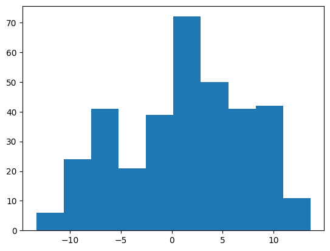

- x2: mean = 0.46 median = 1 these values are close considering the range, which tells us x2 has a symmetrical distribution.

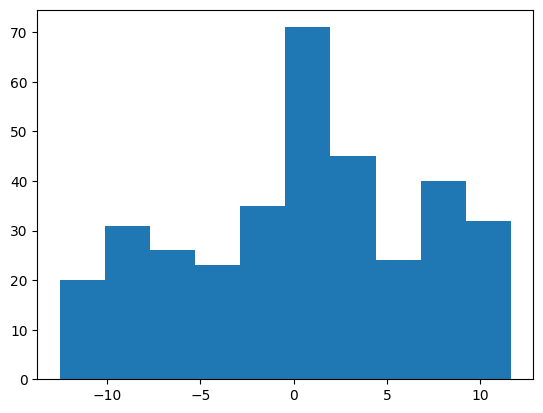

- x3: mean = 3.58 median = 6.39 these values are not close considering the range, which tells us x3 has a distribution that tends to the right (skewed left)

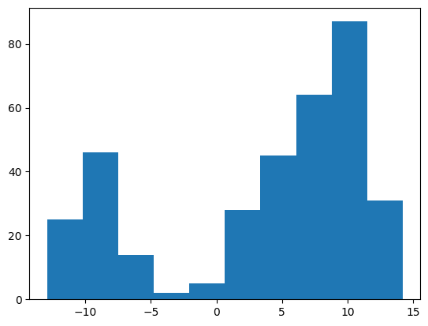

- x4: mean = -1.23 median = -1.48 these values are very close considering the range, which tells us x4 has a symmetrical distribution.

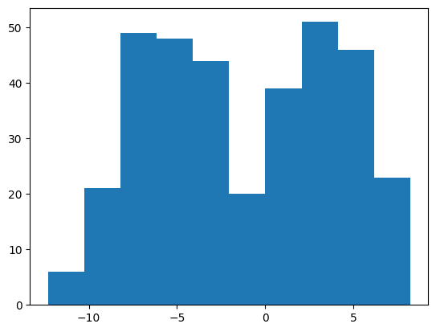

Analyze of the percentiles: In most cases, there is a bigger jump from the 0% - 25% and 75% - 100% percentiles than 25% - 50% and 50% - 75%. This means that most numbers are closer to the median than to the minimun and maximum value.

## A3 Data visualization

Plot in the same figure the histogram of two variables

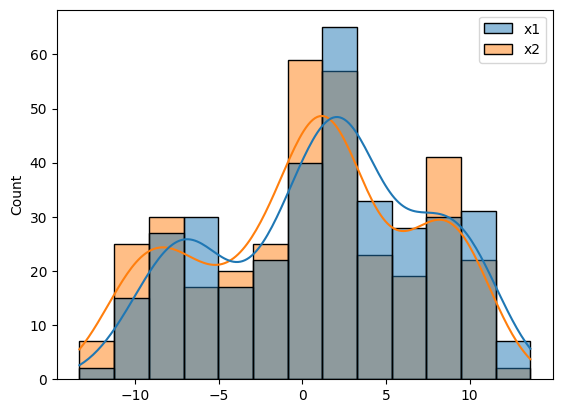

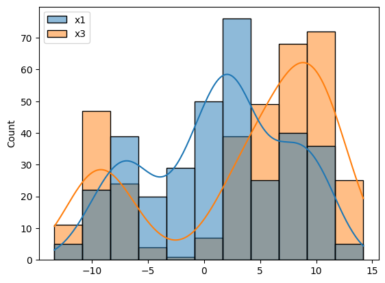

```python
df2plot = df[["x1", "x2"]]
sns.histplot(df2plot, kde = True)
plt.show()

df2plot = df[["x1", "x3"]]
sns.histplot(df2plot, kde = True)
plt.show()
```

Based on these plots, provide a description of your data:

Your response here:

Both x1 and x2 have a symmetrical distribution, and they are almost the same, as we can see thanks to the kde. Their data is different but their behavior is alike.

In the second diagram we compare x1 and x3, and we can see very different behaviors. While x1 is symmetrical, x3 is skewed left (as mentioned in the last description).

Plot in the same figure the boxplot of two variables

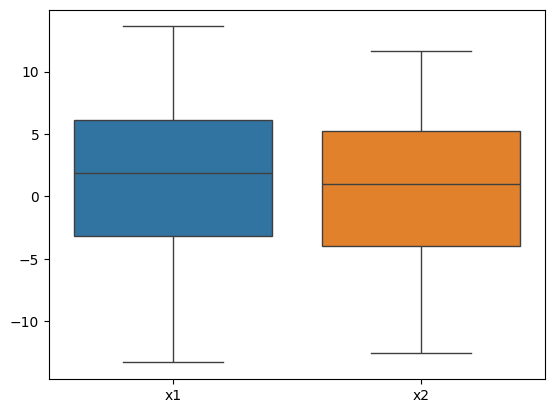

```python
sns.boxplot(data = df[["x1",'x2']])
plt.show()
```

Plot the scatter plot of two variables

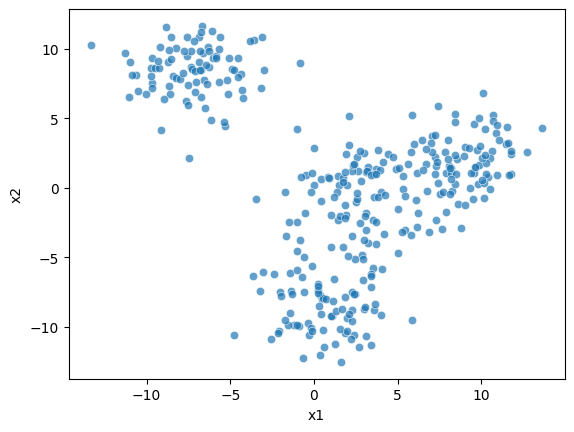

```python
sns.scatterplot(data = df, x = "x1", y= "x2", alpha = 0.7)
plt.show()
```

### Questions

Based on the previos plots, provide a description of yout dataset

Your response:

As an experiment, I added x3. We can see how the green box is not centered, nor its mean, showing us again, that x3 does not have a symmetrical distribution.

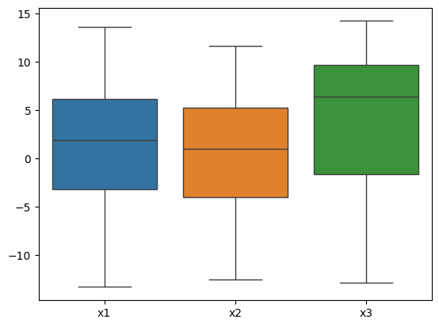

For the scatter plot we used x1 and x2, and got the following information:

- x2 has the highest values when x1 is negative
- when x1 is close to zero, x2 tends to have a value equal or lower than zero
- when x2 is close to zero, x1 tends to have a value equal or higher than zero

## A4 Kmeans

Do Kmeans clustering assuming a number of clusters accorging to your scatter plot

```python
from sklearn.cluster import KMeans

K  = 3

km = KMeans(n_clusters=K, n_init="auto")

# We re-declare the DataFrame to do the KMeans Clustering considering all variables
# (in previous exercises we deleted x4)
df = pd.read_csv(url, index_col= 0)

yestimated = km.fit_predict(df)

yestimated
```

```
array([1, 2, 2, 1, 0, 2, 1, 1, 2, 1, 2, 1, 2, 2, 2, 1, 2, 2, 0, 2, 2, 1,
       2, 2, 2, 2, 0, 0, 2, 2, 2, 1, 1, 0, 1, 2, 2, 1, 2, 1, 2, 2, 1, 0,
       1, 1, 1, 2, 2, 2, 0, 2, 1, 2, 2, 2, 2, 1, 2, 1, 1, 0, 2, 1, 1, 2,
       2, 0, 0, 0, 2, 1, 2, 2, 2, 2, 1, 1, 1, 1, 0, 2, 0, 1, 2, 2, 1, 0,
       0, 2, 0, 1, 2, 0, 0, 2, 0, 2, 1, 2, 0, 2, 2, 2, 1, 2, 2, 2, 0, 2,
       2, 2, 2, 0, 2, 2, 2, 1, 0, 2, 2, 2, 2, 0, 2, 2, 2, 2, 2, 2, 2, 2,
       1, 0, 1, 1, 2, 1, 0, 2, 2, 1, 0, 2, 2, 0, 2, 0, 2, 2, 2, 0, 2, 0,
       1, 0, 2, 1, 0, 0, 2, 0, 2, 1, 1, 2, 0, 0, 0, 0, 1, 1, 1, 2, 1, 0,
       1, 2, 2, 2, 2, 1, 0, 2, 2, 2, 0, 0, 2, 2, 0, 2, 2, 1, 0, 0, 2, 1,
       1, 2, 1, 0, 1, 0, 1, 1, 2, 0, 2, 2, 0, 2, 0, 1, 0, 0, 2, 2, 2, 0,
       2, 2, 1, 1, 1, 2, 1, 1, 2, 2, 2, 0, 0, 2, 0, 0, 2, 2, 2, 2, 1, 0,
       0, 1, 2, 1, 0, 0, 1, 2, 2, 2, 0, 0, 2, 0, 1, 2, 2, 2, 2, 0, 0, 0,
       0, 1, 1, 2, 1, 2, 2, 2, 1, 2, 1, 2, 1, 1, 2, 2, 1, 1, 0, 2, 2, 0,
       2, 1, 2, 1, 0, 2, 0, 1, 2, 0, 0, 2, 1, 1, 1, 0, 0, 0, 2, 2, 0, 2,
       2, 0, 2, 2, 0, 2, 2, 2, 2, 1, 2, 1, 2, 0, 2, 2, 0, 2, 2, 0, 2, 0,
       2, 2, 1, 2, 1, 1, 2, 0, 2, 1, 2, 2, 2, 2, 2, 0, 2])
```

Add to your dataset a column with the estimated cluster to each data point

```python
df['yestimated'] = yestimated
```

Print the number associated to each cluster

```python
df.yestimated.unique()
```

```
array([1, 2, 0])
```

Print the centroids

```python
km.cluster_centers_
```

```
array([[ 0.84734754, -8.24296729, -8.97104597, -6.93061653],
       [-7.11513023,  8.40545069,  9.28123803, -4.39332447],
       [ 5.81432702,  0.81127208,  7.02391021,  3.26588304]])
```

Print the intertia metric

```python
km.inertia_
```

```
9406.650107502028
```

Plot a scatter plot of your data using different color for each cluster. Also plot the centroids

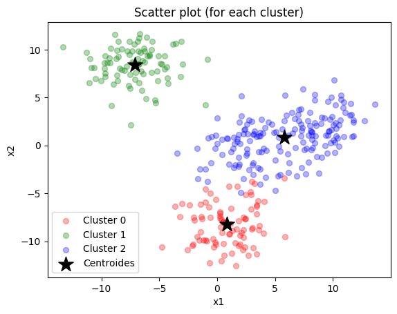

```python
# Get a dataframe with the data of each clsuter
df1 = df[df.yestimated==0]
df2 = df[df.yestimated==1]
df3 = df[df.yestimated==2]


plt.scatter(df1.x1, df1.x2, label='Cluster 0', c='r', marker='o', s=32, alpha=0.3)
plt.scatter(df2.x1, df2.x2, label='Cluster 1', c='g', marker='o', s=32, alpha=0.3)
plt.scatter(df3.x1, df3.x2, label='Cluster 2', c='b', marker='o', s=32, alpha=0.3)


# Plot centrodides
plt.scatter(km.cluster_centers_[:,0], km.cluster_centers_[:,1], color='black', marker='*', label='Centroides', s=256)

plt.title('Scatter plot (for each cluster)')
plt.xlabel('x1')
plt.ylabel('x2')
plt.legend()
plt.show()
```

### Questions

Provides a detailed description of your results

Your response:

I decided to use 3 clusters to do the KMeans Clustering, and the results were excellent. Each centroide clearly represents their cluster. The 2nd cluster (blue) has a wide range in the x1 axis, but I would not recommend adding a 4th cluster, I believe these number of K is optimal for aggrupations.

## A5 Elbow plot

Compute the Elbow plot

```python
# Intialize a list to hold sum of squared error (sse)
sse = []

# Define values of k
k_rng = range(1,10)

# For each k
for k in k_rng:
    # Create model
    km = KMeans(n_clusters=k, n_init="auto")
    # Do K-means clustering
    km.fit_predict(df[['x1','x2']])
    # Save sse for each k
    sse.append(km.inertia_)
```

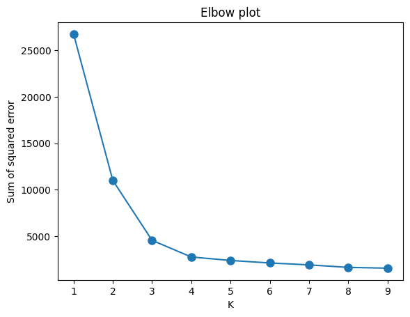

```python
# Plot sse versus k
plt.plot(k_rng,sse, 'o-', markersize=8)

plt.title('Elbow plot')
plt.xlabel('K')
plt.ylabel('Sum of squared error')
plt.show()
```

### Questions

What is the best number of clusters K? (argue your response)

Your response: 3

Does this number of clusters agree with your inital guess? (argue your response, no problem at all if they do not agree)

Your response: It does. I selected this value after seeing the scatter plot. I considered the following groups:

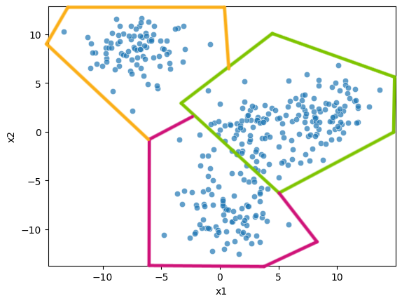

Even though there were two clear groupings in the plot, the second one (lower right) had a big range of values for both x1 and x2. That's why I decided to separate it into 2.

In the end the groups ended up being similar to the actual clusters.

# PART 2

# Descipcion de tu percepcion del nivel de desarrollo de la subcompetencia

### SING0202A Interpretación de variables

Escribe tu description del nivel de logro del siguiente criterio de la subcompetencia

**Interpreta interacciones**. Interpreta interacciones entre variables relevantes en un problema, como base para la construcción de modelos bivariados basados en datos de un fenómeno investigado que le permita reproducir la respuesta del mismo.

Tu respuesta:

Creo que logré un nivel destacado en esta subcompetencia. Al ser una estudiante de programación he tenido la oportunidad de desarrollar esta habilidad durante toda mi carrera, por lo que me siento segura de decir que domino esta subcompentencia. En la semana tec tuvimos la oportunidad de hacer ejercicios prácticos, lo que me permitió comprender las interacciones, pues era sencillo hacer pequeños cambios y ver como afectaba a los laboratorios.

Escribe tu description del nivel de logro del siguiente criterio de la subcompetencia

**Construcción de modelos**. Es capaz de construir modelos bivariados que expliquen el comportamiento de un fenómeno.

Tu respuesta:

De la misma manera creo que logré un nivel destacado en esta subcompetencia. Para la evidencia final no tuve nínguna dificultad para comprender el funcionamiento de los modelos que utilizamos, y pude hacer un análisis profundo sobre cada paso, que significaba, sus consecuencias y su justificación. Sinceramente creo que también dominé esta habilidad.